### Machine Learning - Prediction Assignment Writeup

### Introduction

#### The main goal of the project is to predict the manner in which 6 participants did the exercise. This is the “classe” variable in the training set.Machine learning algorithm will be applied to the 20 different test cases available in the test data.

### Background

#### Using devices such as Jawbone Up, Nike FuelBand, and Fitbit it is now possible to collect a large amount of data about personal activity relatively inexpensively. These type of devices are part of the quantified self movement - a group of enthusiasts who take measurements about themselves regularly to improve their health, to find patterns in their behavior, or because they are tech geeks. One thing that people regularly do is quantify how much of a particular activity they do, but they rarely quantify how well they do it. In this project, your goal will be to use data from accelerometers on the belt, forearm, arm, and dumbell of 6 participants. They were asked to perform barbell lifts correctly and incorrectly in 5 different ways. More information is available from the website here: http://groupware.les.inf.puc-rio.br/har (see the section on the Weight Lifting Exercise Dataset).

### Loading Data and Preprocessing the Data

#### The training data for this project are available at:https://d396qusza40orc.cloudfront.net/predmachlearn/pml-training.csv

#### The test data are available at:https://d396qusza40orc.cloudfront.net/predmachlearn/pml-testing.csv

### Envionrment setup

#### Upload all the required libraries

```r
library(knitr)
library(caret)
library(rpart)
```

```r
library(rpart.plot)
library(randomForest)
```

#### Data Loading and cleaning

##### load the dataset from the URL above. The training dataset is partinioned in 2.

##### Training set (70% of the data) for the modeling process and a Test set (with the remaining 30%) for the validations.

```r
#set the url
Traindata <- "http://d396qusza40orc.cloudfront.net/predmachlearn/pml-training.csv"
Testdata  <- "http://d396qusza40orc.cloudfront.net/predmachlearn/pml-testing.csv"

# download the datasets
training <- read.csv(url(Traindata))
testing  <- read.csv(url(Testdata))

# create a partition with the training dataset
inTrain  <- createDataPartition(training$classe, p=0.7, list=FALSE)
TrainSet <- training[inTrain, ]
TestSet  <- training[-inTrain, ]
dim(TrainSet)
```

```
## [1] 13737   160
```

```r
dim(TestSet)
```

```
## [1] 5885  160
```

#### Train and test datasets has 160 variables.These variables have NA hence need to perform the cleaning of the data, also remove the near zero variance and id variables

```r
# remove variables with Nearly Zero Variance
NZV <- nearZeroVar(TrainSet)
TrainSet <- TrainSet[, -NZV]
TestSet  <- TestSet[, -NZV]
dim(TrainSet)
```

```
## [1] 13737   105
```

```r
dim(TestSet)
```

```
## [1] 5885  105
```

```r
#remove NA variables
removeNA    <- sapply(TrainSet, function(x) mean(is.na(x))) > 0.95
TrainSet <- TrainSet[, removeNA==FALSE]
TestSet  <- TestSet[, removeNA==FALSE]
dim(TrainSet)
```

```
## [1] 13737    59
```

```r
dim(TestSet)
```

```
## [1] 5885   59
```

```r
# remove identification variables
TrainSet <- TrainSet[, -(1:5)]
TestSet  <- TestSet[, -(1:5)]
dim(TrainSet)
```

```
## [1] 13737    54
```

```r
dim(TestSet)
```

```
## [1] 5885   54
```

### Random Forest

```r
# model fit
set.seed(12345)
RFcontrol <- trainControl(method="cv", number=3, verboseIter=FALSE)
modFitRandForest <- train(classe ~ ., data=TrainSet, method="rf",
                          trControl=RFcontrol)
modFitRandForest$finalModel
```

```
##
## Call:
##  randomForest(x = x, y = y, mtry = param$mtry)
##                Type of random forest: classification
##                      Number of trees: 500
## No. of variables tried at each split: 27
##
##         OOB estimate of  error rate: 0.25%
## Confusion matrix:
##      A    B    C    D    E  class.error
## A 3904    1    0    0    1 0.0005120328
## B    4 2650    3    1    0 0.0030097818
## C    0    5 2391    0    0 0.0020868114
## D    0    0   11 2239    2 0.0057726465
## E    0    1    0    6 2518 0.0027722772
```

```r
#Prediction on test dataset
predictRandForest <- predict(modFitRandForest, newdata=TestSet)
confMatRandForest <- confusionMatrix(predictRandForest, TestSet$classe)
confMatRandForest
```

```
## Confusion Matrix and Statistics
##
##           Reference
## Prediction    A    B    C    D    E
##          A 1674    2    0    0    0
##          B    0 1137    3    0    0
##          C    0    0 1023    1    0
##          D    0    0    0  963    2
##          E    0    0    0    0 1080
##
## Overall Statistics
##
##                Accuracy : 0.9986
##                  95% CI : (0.9973, 0.9994)
##     No Information Rate : 0.2845
##     P-Value [Acc > NIR] : < 2.2e-16
##
##                   Kappa : 0.9983
##  Mcnemar's Test P-Value : NA
##
## Statistics by Class:
##
##                      Class: A Class: B Class: C Class: D Class: E
## Sensitivity            1.0000   0.9982   0.9971   0.9990   0.9982
## Specificity            0.9995   0.9994   0.9998   0.9996   1.0000
## Pos Pred Value         0.9988   0.9974   0.9990   0.9979   1.0000
## Neg Pred Value         1.0000   0.9996   0.9994   0.9998   0.9996
## Prevalence             0.2845   0.1935   0.1743   0.1638   0.1839
## Detection Rate         0.2845   0.1932   0.1738   0.1636   0.1835
## Detection Prevalence   0.2848   0.1937   0.1740   0.1640   0.1835
## Balanced Accuracy      0.9998   0.9988   0.9984   0.9993   0.9991
```

### Decision Trees

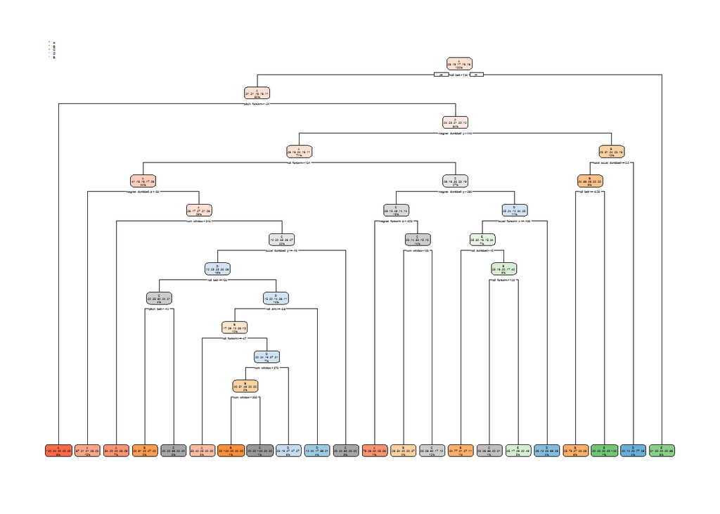

```r
# model fit
set.seed(12345)
modFitDTree <- rpart(classe ~ ., data=TrainSet, method="class")
rpart.plot(modFitDTree)
```

```r
# prediction on test dataset
predictDTree <- predict(modFitDTree, newdata=TestSet, type="class")
confDTree <- confusionMatrix(predictDTree, TestSet$classe)
confDTree
```

```
## Confusion Matrix and Statistics
##
##           Reference
## Prediction    A    B    C    D    E
##          A 1525  256   22   91   86
##          B   50  625   30   21   88
##          C   19   93  874  156   92
##          D   60  116   79  643  123
##          E   20   49   21   53  693
##
## Overall Statistics
##
##                Accuracy : 0.7409
##                  95% CI : (0.7295, 0.752)
##     No Information Rate : 0.2845
##     P-Value [Acc > NIR] : < 2.2e-16
##
##                   Kappa : 0.6705
##  Mcnemar's Test P-Value : < 2.2e-16
##
## Statistics by Class:
##
##                      Class: A Class: B Class: C Class: D Class: E
## Sensitivity            0.9110   0.5487   0.8519   0.6670   0.6405
## Specificity            0.8919   0.9602   0.9259   0.9232   0.9702
## Pos Pred Value         0.7702   0.7678   0.7083   0.6298   0.8289
## Neg Pred Value         0.9618   0.8986   0.9673   0.9340   0.9230
## Prevalence             0.2845   0.1935   0.1743   0.1638   0.1839
## Detection Rate         0.2591   0.1062   0.1485   0.1093   0.1178
## Detection Prevalence   0.3364   0.1383   0.2097   0.1735   0.1421
## Balanced Accuracy      0.9015   0.7545   0.8889   0.7951   0.8054
```

### Conclusion

#### As can be seen from the confusion matrix the Random Forest model is very accurate, the Random Forest model will be applied to predict the 20 quiz results (testing dataset).

```r
PredictionDT <- predict(modFitRandForest,newdata=testing)
PredictionDT
```

```
##  [1] B A B A A E D B A A B C B A E E A B B B
## Levels: A B C D E
```